# Final Project - Near-Earth Asteroids

Braxton Wilson, Richard Sauve

12/13/2021

# Introduction

- Keeping track of NEO’s (near-earth objects) is important for the safety of our satellites, astronauts, and (in the case of large objects) the planet!
- Another good reason to keep track of NEO’s is for the potential, in the future, to be able to mine these asteroids for minerals and water.
- Will be exploring and presenting an NEA (near-earth asteroid) dataset from Kaggle which was compiled from NASA’s CNEOS website.
- Explore the data by comparing hazardous to non-hazardous NEA’s and comparing different classes of NEA’s.
- This analysis will help shed light on the following:
  - What are the differences between Hazardous and Non-Hazardous NEA’s?
  - What are the differences between the classifications of NEA’s?

# Packages Required

```r
# several packages useful for working with dataframes (dplyr, tibbles) and graphs (ggplot2)
library(tidyverse)
# For prettier tables
library(kableExtra)
```

# Data Prep

- Data set downloaded from Kaggle:
  - https://www.kaggle.com/shrutimehta/nasa-asteroids-classification
- Data itself is from NASA
  - http://neo.jpl.nasa.gov/
- This data is public domain and was scraped from NASA’s website by Shruti Mehta in 2017. She says her inspiration for collecting this data was finding potential hazardous and non-hazardous asteroids and understanding what distinguishes the two categories.
- From the NASA CNEOS website’s [about](https://cneos.jpl.nasa.gov/about/) page:

  > The Center for Near-Earth Object Studies (CNEOS) computes high precision orbits for Near-Earth Objects (NEOs), predicts their future motions, assesses their impact hazard, and makes these result available on this website.
- No missing data for any of the variables!
- Import is simple, read.csv.
- A glimpse at the dataframe:

```
## Rows: 4,687
## Columns: 12
## $ Neo.Reference.ID             <int> 3703080, 3723955, 2446862, 3092506, 35147~
## $ Absolute.Magnitude           <dbl> 21.6, 21.3, 20.3, 27.4, 21.6, 19.6, 19.6,~
## $ Max.Est.Dia.KM               <dbl> 0.28447230, 0.32661790, 0.51765448, 0.019~
## $ Min.Est.Dia.KM               <dbl> 0.127219878, 0.146067964, 0.231502122, 0.~
## $ Relative.Velocity.km.per.sec <dbl> 6.115834, 18.113985, 7.590711, 11.173874,~
## $ Miss.Dist.AU                 <dbl> 0.41948253, 0.38301446, 0.05095602, 0.285~
## $ Orbit.Uncertainty            <int> 5, 3, 0, 6, 1, 1, 1, 0, 0, 0, 6, 4, 6, 0,~
## $ Eccentricity                 <dbl> 0.4255491, 0.3516743, 0.3482483, 0.216578~
## $ Semi.Major.Axis              <dbl> 1.4070113, 1.1077760, 1.4588238, 1.255902~
## $ Perihelion.Dist              <dbl> 0.8082589, 0.7181996, 0.9507910, 0.983901~
## $ Aphelion.Dist                <dbl> 2.005764, 1.497352, 1.966857, 1.527904, 1~
## $ Hazardous                    <chr> "Hazardous", "Non-Hazardous", "Hazardous"~
```

### Variables of Interest:

| Variables | Description |
| --- | --- |
| [Neo.Reference.ID](https://naif.jpl.nasa.gov/pub/naif/toolkit_docs/C/req/naif_ids.html#Asteroids) | ID number assigned to the asteroid by NASA |
| [Absolute.Magnitude](https://cneos.jpl.nasa.gov/glossary/h.html) | How visible the asteroid would be from a standardized distance away (1 AU) without any kind of obfuscation |
| [Max.Est.Dia.KM](https://cneos.jpl.nasa.gov/) | The maximum estimation of the NEA’s diameter |
| [Min.Est.Dia.KM](https://cneos.jpl.nasa.gov/) | The minimum estimation of the NEA’s diameter |
| [Relative.Velocity.km.per.sec](https://cneos.jpl.nasa.gov/) | The velocity of the NEA relative to our vantage point |
| [Miss.Dist.AU](https://cneos.jpl.nasa.gov/) | Distance the object missed Earth in astronomical units |
| [Orbit.Uncertainty](https://minorplanetcenter.net//iau/info/UValue.html) | 0-9 logarithmic scale of the uncertainty of an object’s orbit |
| [Eccentricity](https://cneos.jpl.nasa.gov/glossary/eccentricity.html) | Measure of an objects deviation from a circular orbit, 0 = Perfect circle, 0 < and < 1 is an ellipse, 1 is parabolic, and > 1 is hyperbolic |
| [Semi.Major.Axis](https://ssd.jpl.nasa.gov/glossary/semimajor_axis.html) | Half of the major axis of the elliptical orbit |
| [Perihelion.Dist](https://cneos.jpl.nasa.gov/glossary/perihelion.html) | The point in an object’s orbit closest to the sun |
| [Aphelion.Dist](https://cneos.jpl.nasa.gov/glossary/aphelion.html) | The point in an object’s orbit furthest from the sun |
| [Hazardous](https://cneos.jpl.nasa.gov/glossary/PHA.html) | Whether or not the asteroid meets the requirements to be deemed potentially hazardous |

# Exploratory Data Analysis

- When looking through the observations available for NEA’s in this data set, I wondered what made an asteroid “hazardous” or not.
- This was easily answered via NASA’s CNEOS [website](https://cneos.jpl.nasa.gov/about/neo_groups.html):

  > Potentially Hazardous Asteroids (PHAs) are currently defined based on parameters that measure the asteroid’s potential to make threatening close approaches to the Earth. Specifically, all asteroids with an Earth Minimum Orbit Intersection Distance (MOID) of 0.05 au or less and an absolute magnitude (H) of 22.0 or less are considered PHAs. In other words, asteroids that can’t get any closer to the Earth (i.e., MOID) than 0.05 au (roughly 7,480,000 km or 4,650,000 mi) or are smaller than about 140 m (~500 ft) in diameter (i.e., H = 22.0 with assumed albedo of 14%) are not considered PHAs.
- On that same page, a graphic explaining how to calculate NEA classifications was available.

### NEA Classes

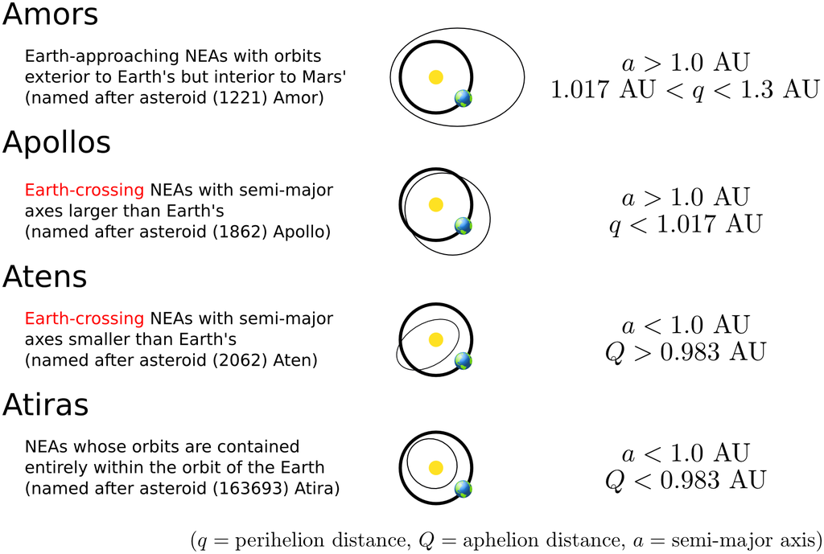

[NEA Classification](https://cneos.jpl.nasa.gov/about/neo_groups.html)

### Hazardous vs Non-Hazaradous by Asteroid Class

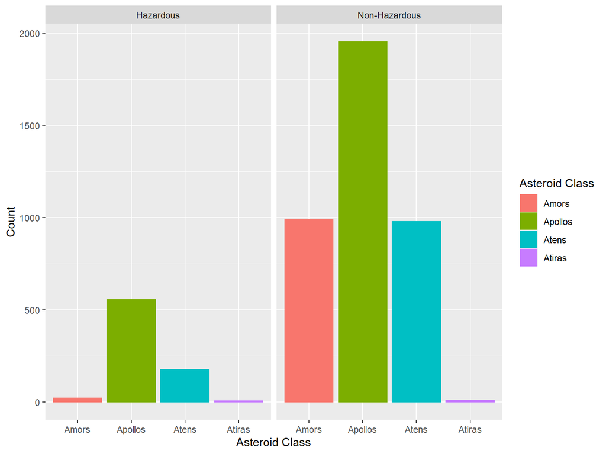

| Asteroid Class | Percentage of Hazardous NEA’s from each class |
| --- | --- |
| Amors | 2.79% |
| Apollos | 73.52% |
| Atens | 23.02% |
| Atiras | 0.67% |

| Asteroid Class | Percentage of NEA Class that is Hazardous |
| --- | --- |
| Amors | 2.23% |
| Apollos | 22.13% |
| Atens | 15.10% |
| Atiras | 35.71% |

### Absolute Magnitude

- Based off the previous definition of a potentially hazardous asteroid, the average absolute magnitude of hazardous asteroids should be lower than that of non-hazardous asteroids.
- The five largest absolute magnitudes:

  | Neo.Reference.ID | Absolute.Magnitude | Hazardous |
  | --- | --- | --- |
  | 3432678 | 32.1 | Non-Hazardous |
  | 3770280 | 30.8 | Non-Hazardous |
  | 3733862 | 30.6 | Non-Hazardous |
  | 3733862 | 30.6 | Non-Hazardous |
  | 3696401 | 30.4 | Non-Hazardous |

- The five smallest absolute magnitudes:

  |  | Neo.Reference.ID | Absolute.Magnitude | Hazardous |
  | --- | --- | --- | --- |
  | 4683 | 2004183 | 14.40 | Hazardous |
  | 4684 | 2004183 | 14.40 | Hazardous |
  | 4685 | 2001685 | 14.23 | Non-Hazardous |
  | 4686 | 2001980 | 13.92 | Non-Hazardous |
  | 4687 | 2000433 | 11.16 | Non-Hazardous |

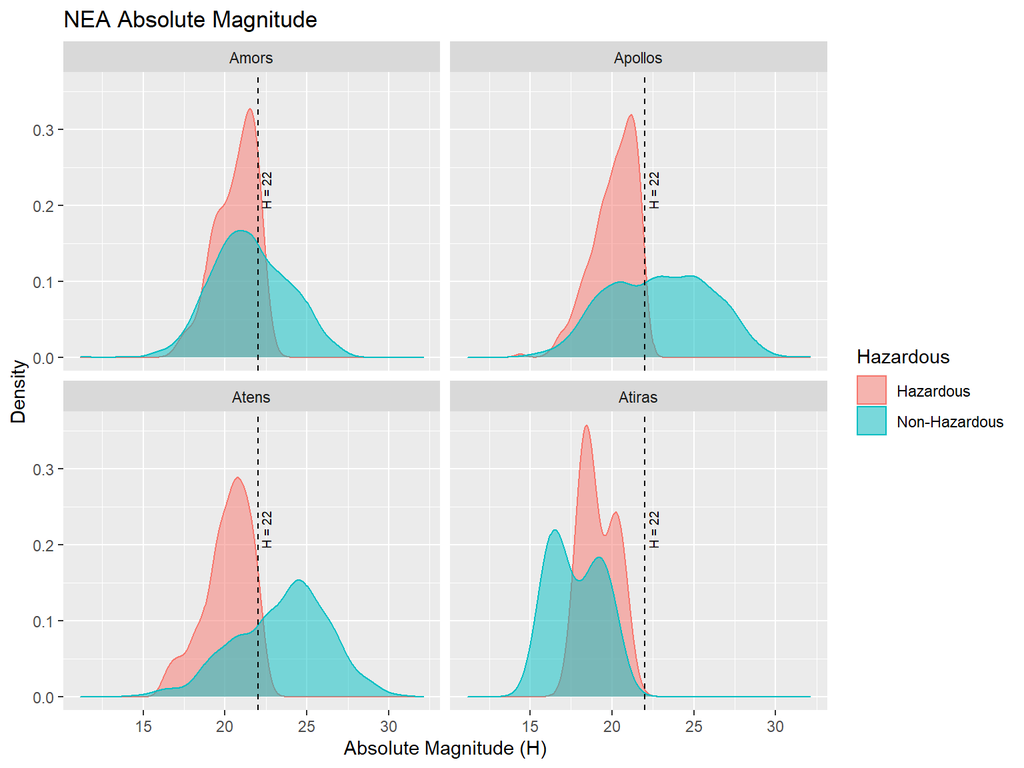

- Summary Statistics

```
## [1] "Hazardous:"
```

```
##    Min. 1st Qu.  Median    Mean 3rd Qu.    Max.
##   14.40   19.30   20.30   20.12   21.20   22.60
```

```
## [1] "Non-Hazardous:"
```

```
##    Min. 1st Qu.  Median    Mean 3rd Qu.    Max.
##   11.16   20.40   22.70   22.68   24.90   32.10
```

- As expected and shown in the density graphs, the absolute magnitude of non-hazardous NEA’s is larger than that of hazardous NEA’s and non-hazardous NEA’s have a much wider range.

### Orbital Uncertainty

- A look at the differences between Hazardous/Non-Hazardous NEA’s and NEA classes of Orbital Uncertainty.

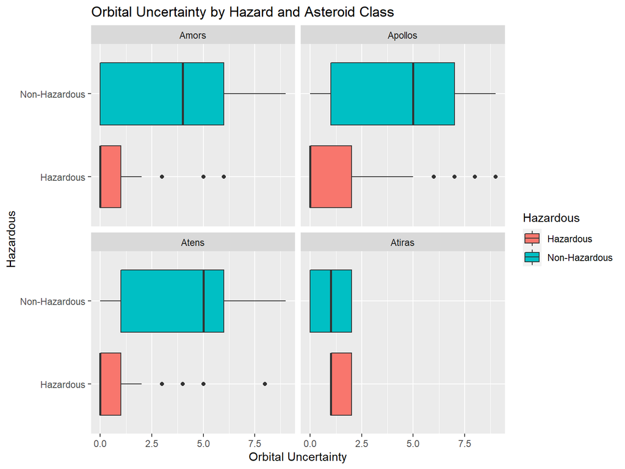

- Hazardous NEA’s have significantly less orbital uncertainty on average than non-hazardous NEA’s excluding Atiras class NEA’s.
- Part of the Orbital Uncertainty parameter’s calculation is the number of observations, so it very well may be the case that astronomers spend more time observing potentially hazardous asteroids.
- There is very little orbital uncertainty in Atiras class NEA’s.

### NEA Size & Velocity

- From the definition of PHA’s, PHA’s should be larger on average than non-hazardous NEA’s.

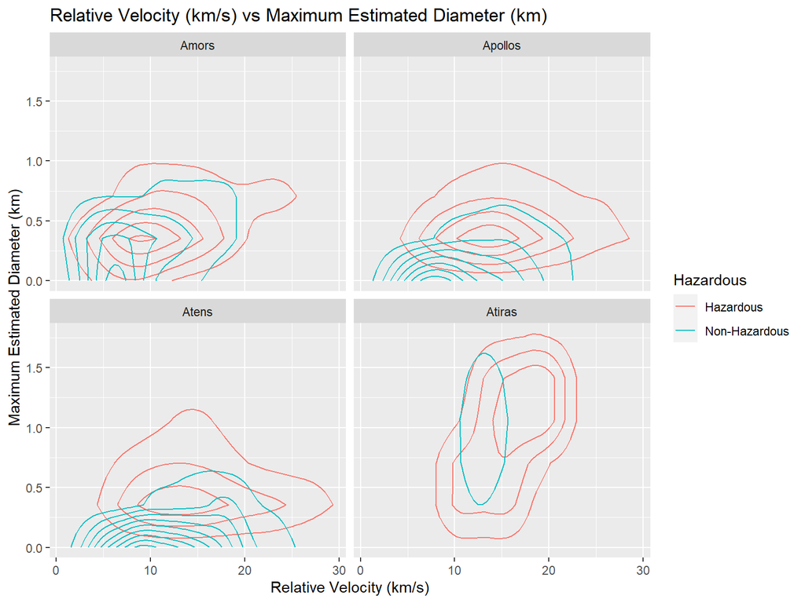

### The Largest Asteroid

| Neo.Reference.ID | Max.Est.Dia.KM | Min.Est.Dia.KM | Hazardous |
| --- | --- | --- | --- |
| 2000433 | 34.836938 | 15.579552 | Non-Hazardous |
| 2001980 | 9.773272 | 4.370740 | Non-Hazardous |
| 2001685 | 8.473054 | 3.789265 | Non-Hazardous |
| 2004183 | 7.835018 | 3.503926 | Hazardous |
| 2004183 | 7.835018 | 3.503926 | Hazardous |

#### 433 Eros

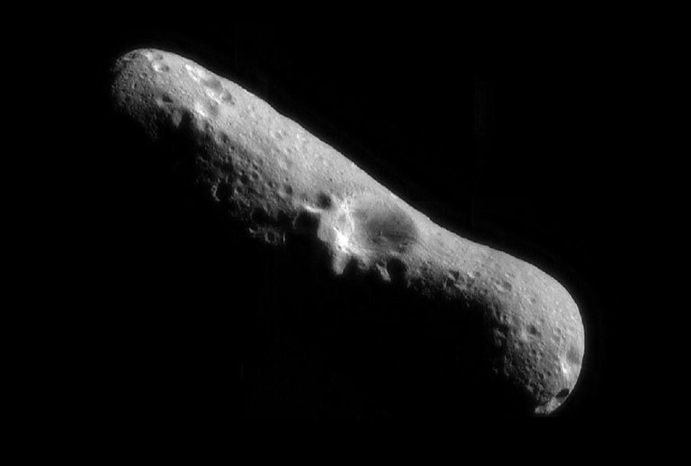

[433 Eros](https://solarsystem.nasa.gov/asteroids-comets-and-meteors/asteroids/433-eros/in-depth/)

- 433 Eros is the first asteroid to be orbited by a satellite and the first to have a satellite land on its surface (NEAR Shoemaker).
- This is an actual photo from NASA’s CNEOS website taken by NEAR Shoemaker.
- 433 Eros is of NEA class Amors and ended up being slightly smaller than expected: 34 km x 11.2 km x 11.2 km
- The asteroid (or comet) that wiped out the dinosaurs is estimated to be 10 km in diameter…
- Thank goodness 433 Eros isn’t Hazardous!

### Perihelion Distance and Eccentricity

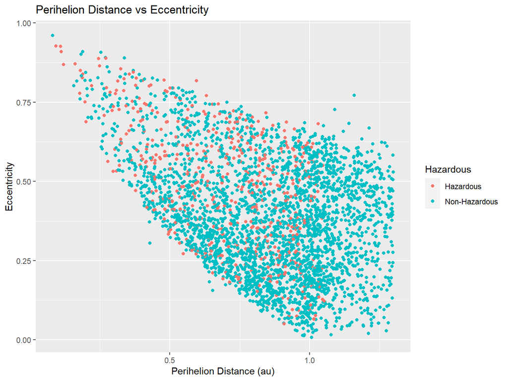

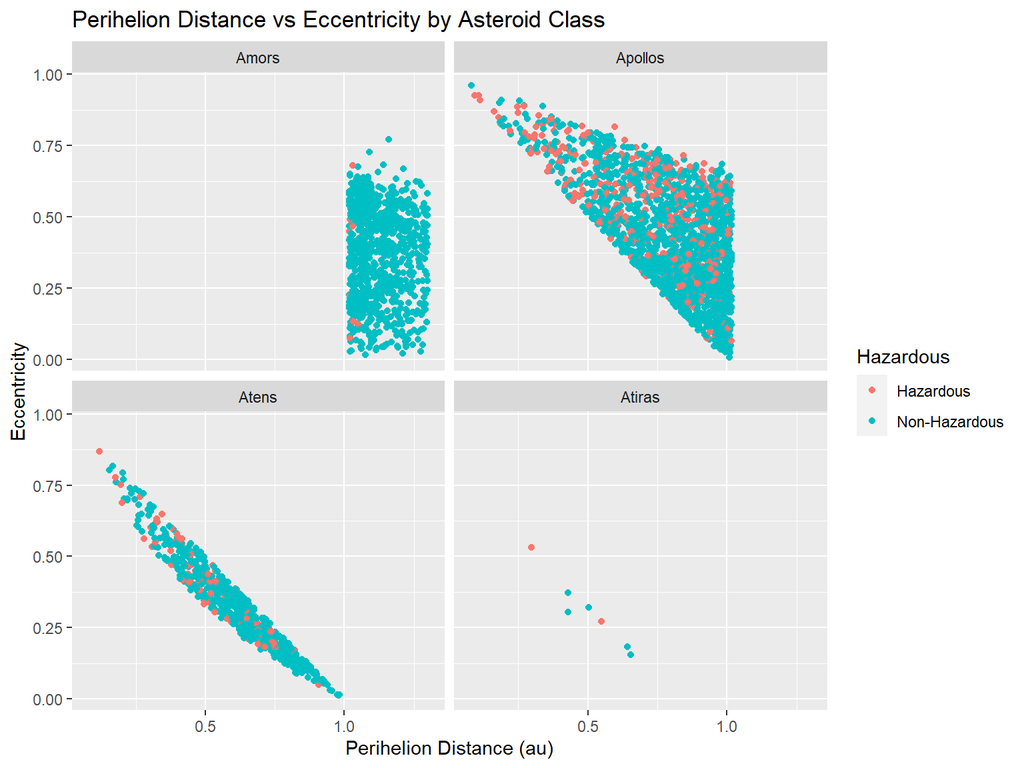

- A nice visual display of how perihelion distance is used to calculate asteroid class.
- Also a nice visual of the relationship between eccentricity and perihelion distance.
- The greater the perihelion distance the lower the eccentricity which is due to eccentricity being used to calculate perihelion distance:
  - P = semi-major axis * (1 - eccentricity).
- This graph also displays the perihelion cut-off for PHA’s (a little above 1 AU).

### Miss Distance

- How close do these objects get to the Earth?

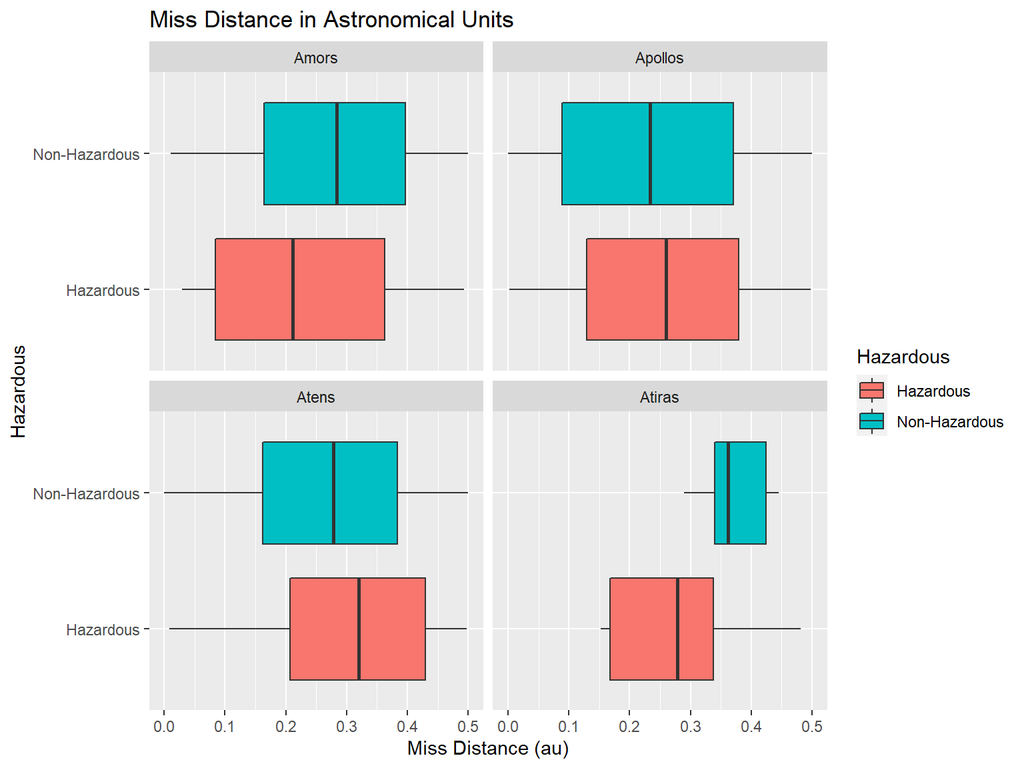

```
## [1] "Hazardous NEA Miss Distance (au) Summary Statistics"
```

```
##     Min.  1st Qu.   Median     Mean  3rd Qu.     Max.
## 0.002172 0.142189 0.280926 0.267560 0.394342 0.498047
```

```
## [1] "Non-Hazardous NEA Miss Distance (au) Summary Statistics"
```

```
##      Min.   1st Qu.    Median      Mean   3rd Qu.      Max.
## 0.0001779 0.1306878 0.2625632 0.2547079 0.3820089 0.4998841
```

- On average non-hazardous NEA’s miss by less than hazardous NEA’s.
  - Looks like a small difference but it’s important to remember that these are measured in astronomical units (1 au is approximately 149,598,000 km).
- Non-hazardous NEA’s are smaller on average so many of them wouldn’t be classified as potentially hazardous even though they miss earth by less distance on average.

# Summary